# Airbnb Listing Price Prediction Analysis

Yash Singh

# *Introduction*

This report presents the analysis and prediction of Airbnb listing prices using R. We’ll cover data import, cleaning, exploratory data analysis (EDA), modeling, evaluation, and findings.

# *Importing data and required library*

```r
library(readr)
library(dplyr)
```

```r
library(ggplot2)

listings <- read_csv("/Users/yashsingh/Desktop/listings.csv")
```

The dataset used in this analysis is from Airbnb’s official website, containing essential information such as listing id, price, host details, and geographical data.

# *Cleaning data and transformation*

```r
# Check for missing values
missing_values <- colSums(is.na(listings))
print(missing_values)
```

```
##                             id                           name
##                              0                              0
##                        host_id                      host_name
##                              0                              0
##            neighbourhood_group                  neighbourhood
##                           8945                              0
##                       latitude                      longitude
##                              0                              0
##                      room_type                          price
##                              0                           3491
##                 minimum_nights              number_of_reviews
##                              0                              0
##                    last_review              reviews_per_month
##                            960                            960
## calculated_host_listings_count               availability_365
##                              0                              0
##          number_of_reviews_ltm                        license
##                              0                             96
```

```r
# Clean data: Drop columns with high missing values, remove rows with missing price,
# and fill missing reviews_per_month
listings_cleaned <- listings %>%
  select(-neighbourhood_group, -license) %>%
  filter(!is.na(price)) %>%
  mutate(reviews_per_month = ifelse(is.na(reviews_per_month), 0, reviews_per_month))


listings_cleaned <- listings_cleaned %>%filter(!is.na(last_review))
```

# *Exploratory Data Analysis (EDA)*

## 1. Plot histogram of price distribution

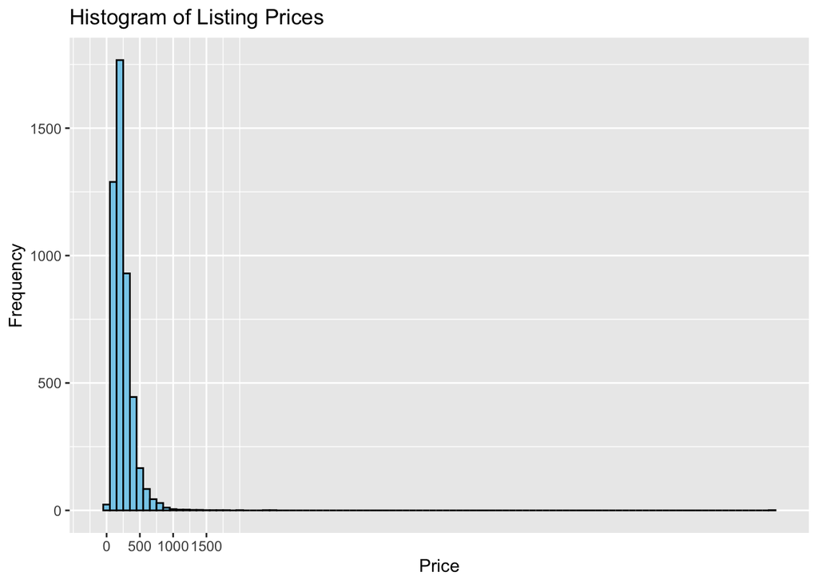

```r
  ggplot(listings_cleaned, aes(x = price)) +
  geom_histogram(binwidth = 100, fill = "skyblue", color = "black") +
  labs(x = "Price", y = "Frequency", title = "Histogram of Listing Prices")+
    scale_x_continuous(breaks = seq(0, 1500, by = 500))
```

**Outcome :** Most of the listings on AirBnB our priced under 500 dollars